# Control structures

10/08/2019

## Control structures

Control structures allow controlling the order in which R expressions are executed. This order of expressions is called the flow of execution. R contains the standard set of control structures that you would expect from a programming language:

- Conditional statements/expressions
  - `if`, `else`, `else if`
  - `switch`
- Loops
  - `for`
  - `repeat`
  - `while`
  - auxiliary expressions: `break` and `next`

## Outline

- Motivation
- Relational operators
- Logical operators
- `if`, `else`, `else if` statements
  - Using `ifelse()` and `dplyr::if_else()`
- `switch`
  - Using `purrr::when()`
- `for` loop
  - Using `lapply`
- `while` loop
- `repeat` loop
- Auxiliary expressions: `break` and `next`

## Motivation

Depending on the day of the week, I am having a different type of breakfast. If it is a working day, I cook an oatmeal.

I want R to display what I will have for breakfast.

## Motivation

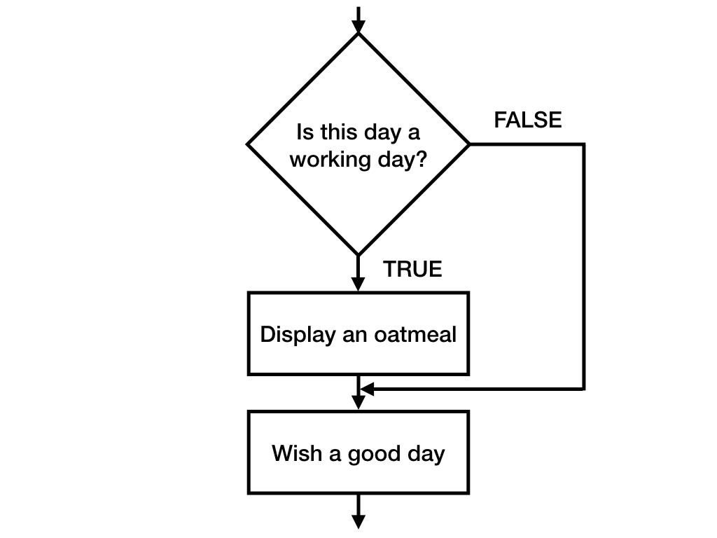

## Motivation

```r
working_day <- TRUE
if (working_day) {
    print("You will have an oatmeal.")
}
```

```
## [1] "You will have an oatmeal."
```

```r
print("Have a nice day!")
```

```
## [1] "Have a nice day!"
```

## Motivation

```r
working_day <- FALSE
if (working_day) {
    print("You will have an oatmeal.")
}
print("Have a nice day!")
```

```
## [1] "Have a nice day!"
```

## Relational operators

Let’s code `working_day` as a number, that is Monday corresponds to `1`, Tuesday corresponds to `2`, and so on.

In order to see whether the day is a working day, we need to compare it with `6`. If it is smaller than `6`, it is a working day, and the breakfast is the oatmeal.

How to do this?

## Relational operators

We can use the binary operator `<`, which allow the comparison of values in atomic vectors:

```r
today <- 2
today < 6
```

```
## [1] TRUE
```

```r
if (today < 6) {
    print("You will have an oatmeal.")
}
```

```
## [1] "You will have an oatmeal."
```

```r
print("Have a nice day!")
```

```
## [1] "Have a nice day!"
```

## Relational operators

Other relational operators are pretty self-explanatory:

```r
x < y
x > y
x <= y
x >= y
x == y
x != y
```

```r
34 < 12
```

```
## [1] FALSE
```

```r
1998 != 12
```

```
## [1] TRUE
```

## Relational operators

These operators are vectorized, that is one can pass atomic vectors with length greater than one, and the comparison will be performed element by element.

```r
c(3, 5, 10) < c(6, 1, 10)
```

```
## [1]  TRUE FALSE FALSE
```

*Note:* The elements of shorter vectors are recycled as necessary.

```r
c(1, 10) < 1:6
```

```
## [1] FALSE FALSE  TRUE FALSE  TRUE FALSE
```

## Relational operators

It is possible to apply these operators to character vectors. In this case, comparison of strings in character vectors is lexicographic.

```r
"a" < "x"
```

```
## [1] TRUE
```

```r
"aa" < "ab"
```

```
## [1] TRUE
```

```r
c("aaa", "abb") < c("aax", "c")
```

```
## [1] TRUE TRUE
```

## Relational operators

Relational operators work only with atomic vectors (or objects that can be coerced to them).

```r
list(2, 3) < list(4, 10)
```

```
## Error in list(2, 3) < list(4, 10): comparison of these types is not implemented
```

*Note:* Mind an implicit coercion!

```r
c(2, 3) < list(4, 10)
```

```
## [1] TRUE TRUE
```

## Relational operators

There are other useful functions:

```r
is.na(23); is.null(NULL) # is.nan(34)
```

```
## [1] FALSE
```

```
## [1] TRUE
```

```r
identical(mtcars, iris) # all.equal()
```

```
## [1] FALSE
```

```r
"words" %in% c("set", "of", "words")
```

```
## [1] TRUE
```

## Exercise

Let’s keep `today` as a character, which stores today’s day of the week. How should the `if` statements be modified in this case?

```r
today <- weekdays(Sys.Date()) # "Tuesday"

if (please_fill_up_this_line){
    print("You will have an oatmeal.")
}
print("Have a nice day!")
```

## Solution

```r
today <- weekdays(Sys.Date())

if(today %in% c("Monday", "Tuesday", "Wednesday", "Thursday", "Friday")) {
    print("You will have an oatmeal.")
}
```

```
## [1] "You will have an oatmeal."
```

```r
print("Have a nice day!")
```

```
## [1] "Have a nice day!"
```

## Logical operators

Sometimes, if I have to wake up at 6:30 am **AND** the day is a working one, then I skip the breakfast. The logical operator that corresponds to **AND** is `&&` (and `&`):

```r
today <- 2
late <- FALSE

if(today < 6 && late) {
    print("You will have an oatmeal.")
}
print("Have a nice day!")
```

```
## [1] "Have a nice day!"
```

Further, the logical equivalent of **OR** in R is `||` and `|`.

## Logical operators

The longer form (`&&` and `||`) evaluates only the first elements of vectors:

```r
c(TRUE, FALSE, FALSE) || c(FALSE, FALSE, FALSE)
```

```
## [1] TRUE
```

The shorter form (`&` and `|`) performs element-wise comparisons:

```r
c(TRUE, FALSE, FALSE) | c(FALSE, FALSE, FALSE)
```

```
## [1]  TRUE FALSE FALSE
```

*Note:* Mind recycling when vectors are of different length.

## Logical operators

R uses *short-circuiting* or *short-circuit evaluation*: the second argument is executed or evaluated only if the first argument does not suffice to determine the value of the expression (only works for longer version).

```r
a
```

```
## Error in eval(expr, envir, enclos): object 'a' not found
```

```r
TRUE || a
```

```
## [1] TRUE
```

```r
TRUE | a
```

```
## Error in eval(expr, envir, enclos): object 'a' not found
```

## Logical operators

*Short-circuiting*:

```r
a
```

```
## Error in eval(expr, envir, enclos): object 'a' not found
```

```r
FALSE && a
```

```
## [1] FALSE
```

```r
FALSE & a
```

```
## Error in eval(expr, envir, enclos): object 'a' not found
```

## Logical operators

Tricks with `NA`:

```r
NA | TRUE
```

```
## [1] TRUE
```

```r
NA | FALSE
```

```
## [1] NA
```

```r
NA & TRUE
```

```
## [1] NA
```

## Exercise

What the expression `NA & FALSE` will return?

## Solution

```r
NA & FALSE
```

```
## [1] FALSE
```

## Logical operators

The name of the vector `late` has ambiguous meaning. Why not use `early_wake_up` instead? Then, we have to somehow negate this vector (change from `TRUE` to `FALSE`, and vice versa). We have an operator `!`:

```r
today <- 2
early_wake_up <- TRUE

if (today < 6 && !early_wake_up) {
    print("You will have an oatmeal.")
}
print("Have a nice day!")
```

```
## [1] "Have a nice day!"
```

*Note:* In R we also have `xor()`.

## Functions `all()` and `any()`

- `all()`: given a set of logical vectors, are all of the values true?
- `any()`: given a set of logical vectors, is at least one of the values true?

```r
x <- c(TRUE, FALSE, TRUE, TRUE)
all(x)
```

```
## [1] FALSE
```

```r
any(x)
```

```
## [1] TRUE
```

## `if`

We have already implicitly defined the `if` control structure. Let’s do it formally:

```r
if (condition) {
    block_of_code
}
```

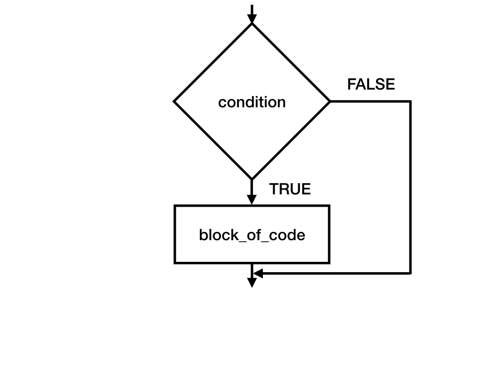

## `if/else`

In our small code snippet we are missing the case when the day is not a working day (i.e., `else` case). During weekends I eat eggs & bacon.

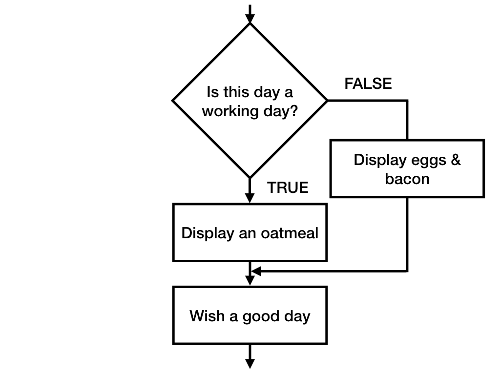

## `if/else`

```r
today <- 2
if (today < 6) {
    print("You will have an oatmeal.")
} else {
    print("You will have eggs & bacon.")
}
```

```
## [1] "You will have an oatmeal."
```

```r
print("Have a nice day!")
```

```
## [1] "Have a nice day!"
```

## `if/else`

```r
today <- 6
if (today < 6) {
    print("You will have an oatmeal.")
} else {
    print("You will have eggs & bacon.")
}
```

```
## [1] "You will have eggs & bacon."
```

```r
print("Have a nice day!")
```

```
## [1] "Have a nice day!"
```

## `if/else`

Again, formally…

```r
if (condition) {
    block_of_code1
} else {
    block_of_code2
}
```

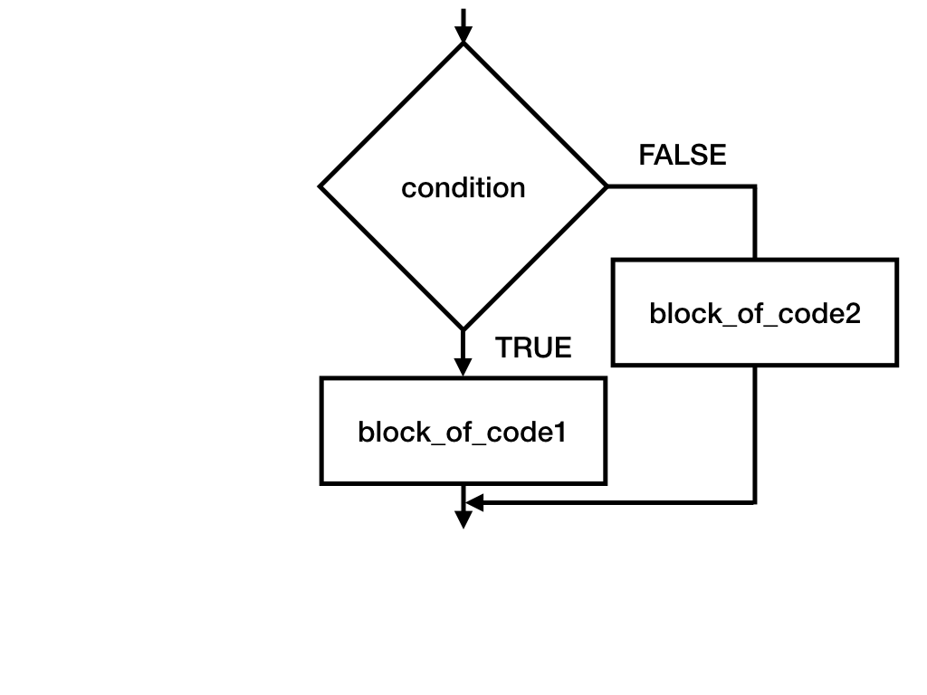

## Nested `if`s and `else if`

Actually, on Saturday I have croissants with a hot сhocolate. Of course, R allows for nested `if` statements:

```r
today <- 6
if (today < 6) {
    print("You will have an oatmeal.")
} else {
    if (today == 6) {
        print("You will have croissants & сhocolate.")
    }
    if (today == 7) {
        print("You will have eggs & bacon.")
    }
}
```

```
## [1] "You will have croissants & сhocolate."
```

But that looks ugly and not very readable.

## Nested `if`s and `else if`

Instead, one can use `else if`:

```r
today <- 6
if (today < 6) {
    print("You will have an oatmeal.")
} else if (today == 6) {
    print("You will have croissants & сhocolate.")
} else {
    print("You will have eggs & bacon.")
}
```

```
## [1] "You will have croissants & сhocolate."
```

## Nested `if`s and `else if`

*Note:* One can have as many `else if`s as needed. Further, `else` case is again not necessary.

```r
today <- 6
if (today < 6) {
    print("You will have an oatmeal.")
} else if (today == 6) {
    print("You will have croissants & сhocolate.")
} else if (today == 7) {
    print("You will have eggs & bacon.")
}
```

```
## [1] "You will have croissants & сhocolate."
```

## Notes on style guide

Put a space before left parentheses:

```r
# Good
if (debug)

# Bad
if(debug)
```

## Notes on style guide

An opening curly brace should NEVER go on its own line and should always be followed by a new line.

```r
# Good
if (is_used) {
    # do something
}
if (is_used) {
    # do something
} else {
    # do something else
}

# Bad
if (is_used)
{
    # do something
}
if (is_used) { # do something }
```

## Notes on style guide

A closing curly brace should always go on its own line, unless it’s followed by `else` or `else if`.

```r
# Good
if (is_used) {
    # do something
} else {
    # do something else
}

# Bad
if (is_used) {
    # do something
}
else {
    # do something else
}
```

## Notes on style guide

Always indent the code inside curly braces!!!

```r
# Good
if (is_used) {
    # do something
    # and then something else
}

# Bad
if (is_used) {
# do something
# and then something else
}
```

## Notes on style guide

Curly braces and new lines can be avoided, if a statement after if is very short.

```r
# Good
if (is_used) return(rval)
```

## Functions `ifelse()` and `dplyr::if_else()`

`ifelse` returns a value with the same shape as test which is filled with elements selected from either `yes` or `no` depending on whether the element of test is TRUE or FALSE.

```r
x <- 1:6
ifelse(x <= 3, rep("<=3", 6), rep(">3", 6))
```

```
## [1] "<=3" "<=3" "<=3" ">3"  ">3"  ">3"
```

## Functions `ifelse()` and `dplyr::if_else()`

If `yes` or `no` are too short, their elements are recycled. `yes` will be evaluated if and only if any element of test is `TRUE`, and analogously for `no`.

```r
x <- 1:6
ifelse(x <= 3, "<=3", ">3")
```

```
## [1] "<=3" "<=3" "<=3" ">3"  ">3"  ">3"
```

```r
x <- 1:6
ifelse(x <= 7, "<=7", log("a"))
```

```
## [1] "<=7" "<=7" "<=7" "<=7" "<=7" "<=7"
```

## Functions `ifelse()` and `dplyr::if_else()`

```r
mtcars$powerful <- ifelse(mtcars$hp >= 200, TRUE, FALSE)
head(mtcars, n = 2)
```

```
##               mpg cyl disp  hp drat    wt  qsec vs am gear carb powerful
## Mazda RX4      21   6  160 110  3.9 2.620 16.46  0  1    4    4    FALSE
## Mazda RX4 Wag  21   6  160 110  3.9 2.875 17.02  0  1    4    4    FALSE
```

```r
library(dplyr)
mtcars <- mtcars %>%
    mutate(powerful = ifelse(hp >= 200, TRUE, FALSE))
head(mtcars, n = 2)
```

```
##   mpg cyl disp  hp drat    wt  qsec vs am gear carb powerful
## 1  21   6  160 110  3.9 2.620 16.46  0  1    4    4    FALSE
## 2  21   6  160 110  3.9 2.875 17.02  0  1    4    4    FALSE
```

## Functions `ifelse()` and `dplyr::if_else()`

Compared to the `base` `ifelse()`, this function is more strict. It checks that `true` and `false` are the same type.

```r
if_else(1:10 < 5, true = 2, false = "a")
```

```
## `false` must be a double vector, not a character vector
```

This strictness makes the output type more predictable, and makes it somewhat faster. One can also specify the replacement of missing values.

## Function `switch()`

What if I have a distinct breakfast for each day of the week? In this case, we can use `switch()` function to have more than two alternatives:

```r
today <- weekdays(Sys.Date())
switch(today,
       Monday = "oatmeal with banana",
       Tuesday = "pure oatmeal",
       Wednesday = "oatmeal with strawberries",
       Thursday = "oatmeal with blueberries",
       Friday = "oatmeal with raspberry",
       Saturday = "croissants & сhocolate",
       Sunday = "eggs & bacon"
)
```

```
## [1] "pure oatmeal"
```

Alternatives can be wrapped into quotation marks (`"Sunday"`).

## Function `purrr::when()`

```r
today <- weekdays(Sys.Date())
purrr::when(today,
    . == "Monday" ~ "oatmeal with banana",
    . == "Tuesday" ~ "pure oatmeal",
    . == "Wednesday" ~ "oatmeal with strawberries",
    . == "Thursday" ~ "oatmeal with blueberries",
    . == "Friday" ~ "oatmeal with raspberry",
    . == "Saturday" ~ "croissants & сhocolate",
    . == "Sunday" ~ "eggs & bacon"
)
```

```
## [1] "pure oatmeal"
```

## `for` loop

We have a bunch of dates, and we need to define which breakfast I will have. These dates are stored in a vector `days`. A crude approach:

```r
days <- Sys.Date() + sample(1:10)

if (weekdays(days[[1]]) %in% c("Sunday", "Saturday")) {
    print("eggs & bacon")
} else {
    print("oatmeal")
}

if (weekdays(days[[3]]) %in% c("Sunday", "Saturday")) {
    print("eggs & bacon")
} else {
    print("oatmeal")
}

# ...
```

## `for` loop

Have you spotted an mistake in the script?

Basically, the same block of code should be repeated ten times. We need a tool that will execute the same code chunk a certain number of times using each element from `days`.

## `for` loop

We have this tool and it is called `for` loop:

```r
for (element in vector) {
    expression
}
```

`for` loop executes `expression` the same number of times (iterations) as a length of `vector`. At the same time iterator variable `element` is assigned to successive values from this `vector`. Typically `expression` does something or use this `element`.

## `for` loop

```r
days <- Sys.Date() + sample(1:10)

for (day in days) {
    if (weekdays(as.Date(day, origin = "1970-01-01"))
        %in% c("Sunday", "Saturday")) {
        print("eggs & bacon")
    } else {
        print("oatmeal")
    }
}
```

```
## [1] "oatmeal"
## [1] "eggs & bacon"
## [1] "oatmeal"
## [1] "oatmeal"
## [1] "oatmeal"
## [1] "oatmeal"
## [1] "oatmeal"
## [1] "oatmeal"
## [1] "eggs & bacon"
## [1] "oatmeal"
```

## `for` loop

`for` loops work with all types of vectors, e.g., atomic vectors:

```r
sizes <- c(3, 5)
for(to in sizes) {
    print(seq(from = 1, to = to))
}
```

```
## [1] 1 2 3
## [1] 1 2 3 4 5
```

```r
colors_set <- c("red", "black")
for(color in colors_set) {
    print(color)
}
```

```
## [1] "red"
## [1] "black"
```

## `for` loop

…and lists.

```r
my_list <- list("string", 2:3, TRUE)
for(element in my_list) {
    print(element)
}
```

```
## [1] "string"
## [1] 2 3
## [1] TRUE
```

## `for` loop

Nevertheless, it is possible to iterate over indices, rather than elements of a vector:

```r
colors_set <- c("red", "black", "green", "yellow")
for(i in 1:length(colors_set)) { # or use seq_along(colors_set)
    print(colors_set[i])
}
```

```
## [1] "red"
## [1] "black"
## [1] "green"
## [1] "yellow"
```

## `for` loop

Iterating over indices is less desirable (requires subseting in the loop and writing more code). Sometimes, however, it might be the only solution (e.g., modifying elements of the vector).

```r
mess <- list("some", pi, TRUE)
for(i in seq_along(mess)) {
    if(is.numeric(mess[[i]])) mess[[i]] <- mess[[i]] * 10
}
mess
```

```
## [[1]]
## [1] "some"
##
## [[2]]
## [1] 31.41593
##
## [[3]]
## [1] TRUE
```

## `for` loop

In R, `for` loops can be nested:

```r
matrix_1999 <- matrix(data = 1:4, nrow = 2, ncol = 2, byrow = TRUE)

for(i in 1:nrow(matrix_1999)) {
    for(j in 1:ncol(matrix_1999)) {
        print(matrix_1999[i,j])
    }
}
```

```
## [1] 1
## [1] 2
## [1] 3
## [1] 4
```

## `for` loop

Let us consider the following example:

```r
grades <- list(
    jack = c(6.0, 5.5, 3.5, 5.5),
    bob = c(2.0, 5.5, 4.5, 3.5),
    stacy = c(5.5, 5.5, 5.0, 5.5, 5.5)
)

for(person in grades) {
    print(mean(person))
}
```

```
## [1] 5.125
## [1] 3.875
## [1] 5.4
```

## `lapply()` function

This can be done in a way more elegant way, that is using `lapply()` function. This function has two main arguments, namely, a vector `X` and a function `FUN` that is applied to each element of `X`. In other words, `lapply()` returns a list of the same length as `X`, each element of which is the result of applying `FUN` to the corresponding element of `X`.

## `lapply()` function

```r
grades <- list(
    jack = c(6.0, 5.5, 3.5, 5.5),
    bob = c(2.0, 5.5, 4.5, 3.5),
    stacy = c(5.5, 5.5, 5.0, 5.5, 5.5)
)

lapply(grades, mean)
```

```
## $jack
## [1] 5.125
##
## $bob
## [1] 3.875
##
## $stacy
## [1] 5.4
```

## `lapply()` function

One can specify optional arguments of `FUN` in `...` argument:

```r
grades <- list(
    jack = c(6.0, 5.5, 3.5, NA)
)
lapply(grades, mean)
```

```
## $jack
## [1] NA
```

```r
grades <- list(
    jack = c(6.0, 5.5, 3.5, NA)
)
lapply(grades, mean, na.rm = TRUE)
```

```
## $jack
## [1] 5
```

## `lapply()` function and friends

There is a whole family of `*apply` functions:

- `sapply()` works as `lapply()` but simplifies the return value
- `vapply()` works as `sapply()` but has a pre-specified type of the return value
- `eapply()` applies `FUN` to the elements of environment
- `apply()` applies `FUN` to a specific margin of a matrix/array
- `tapply()` applies `FUN` to each cell of a ragged array
- `mapply()` applies `FUN` to the first elements of each `...` argument

## `lapply()` function

This function is proffered over the `for` loop because it requires less typing, and therefore, improves readability of the scripts.

The fact that `lapply()` function is faster than the loop is a myth.

## `while` loop

`while` loop will execute the block of code while `condition` inside parentheses is `TRUE`. In other words, until the moment when `condition` after the keyword `while` becomes `FALSE`, the while loop will keep iterating.

```r
while(condition) {
    expression
}
```

This loop is almost never used except maybe for tasks involving simulations and web-scraping.

**Caution:** Beware of an (endless) infinite loop.

## `while` loop

```r
set.seed(6)
r <- rnorm(1)
while (r > -1) {
    print(r)
    r <- rnorm(1)
}
```

```
## [1] 0.269606
## [1] -0.6299854
## [1] 0.8686598
## [1] 1.727196
## [1] 0.02418764
## [1] 0.3680252
```

## `repeat` loop

`repeat` initiates an infinite loop right from the start. The only way to exit a `repeat` loop is to call `break`.

```r
repeat {
    expression
}
```

It is better to avoid this kind of loop.

## `break` and `next`

`next` is used to skip an iteration of a loop.

```r
set.seed(1)
nums <- rnorm(5)
nums
```

```
## [1] -0.6264538  0.1836433 -0.8356286  1.5952808  0.3295078
```

```r
for(num in nums) {
    if (num > 0) next
    print(num)
}
```

```
## [1] -0.6264538
## [1] -0.8356286
```

## `break` and `next`

`break` is used to exit a loop immediately, regardless of what iteration the loop may be on.

```r
set.seed(1)
nums <- rnorm(5)
nums
```

```
## [1] -0.6264538  0.1836433 -0.8356286  1.5952808  0.3295078
```

```r
for(num in nums) {
    if (num > 0) break
    print(num)
}
```

```
## [1] -0.6264538
```

## Other breakfast meals I like

- Pancakes with a salmon fish
- Croissants
- Eggs Benedict with Hollandaise Sauce
- French omlet
- Crispy hash browns with bacon, fried onions, mushrooms and cheese

## References

- [An Introduction to Statistical Programming Methods with R](https://smac-group.github.io/ds/)
- [R Programming for Data Science](https://bookdown.org/rdpeng/rprogdatascience/)
- [Quick R](https://www.statmethods.net)